# 01 Prosecutors

J Andres Gannon, Danil Gromakov, Katelyn Hess, and Yulia Krylova

May 2020

This document loads, cleans, and processes newly collected data on prosecutor’s appointment during the Trump administration. We collect data on their demographic information, employment history, education history, and membership in various organizations to identify patterns in how these prosecutors were chosen.

# Base data

## Load

We load a list of prosecutors with some initial information like their unique wikidata ID, when they were appointed, and whether they were appointed by Barr

```r
# df <- googlesheets4::read_sheet(ss = "https://docs.google.com/spreadsheets/d/1hPOBOyTujUReQzpjZ9PqIhj23V5C74EygMnmXIi6BgI/edit?usp=sharing",
#                                  sheet = "prosecutors_list")

df <- read.csv(file = paste0(here::here(), '/data/raw/TrumpProsecutors - prosecutors_list.csv'))

df <- janitor::clean_names(df)
```

## Summarize basic info

```r
DT::datatable(df)
```

|  | district | attorney | wikidata_id | date_of_appointment | end_date | interim_confirmed | interim_awaiting | barr_appointment | notes |
| --- | --- | --- | --- | --- | --- | --- | --- | --- | --- |
| 1 | U.S. Attorney for the M.D. of Alabama | Louis V. Franklin | Q30508807 | 9/21/2017 |  |  |  | 0 |  |
| 2 | U.S. Attorney for the N.D. of Alabama | Jay Town | Q32178229 | 8/11/2017 |  |  |  | 0 |  |
| 3 | U.S. Attorney for the S.D. of Alabama | Richard W. Moore | Q32171993 | 9/22/2017 |  |  |  | 0 |  |
| 4 | U.S. Attorney for the District of Alaska | Bryan Schroder | Q38831261 | 11/21/2017 |  |  |  | 0 |  |
| 5 | U.S. Attorney for the District of Arizona | Michael G. Bailey | Q61750281 |  |  |  |  | 1 |  |
| 6 | U.S. Attorney for the E.D. of Arkansas | J. Cody Hiland | Q39439933 | 10/10/2017 |  |  |  | 0 |  |
| 7 | U.S. Attorney for the W.D. of Arkansas | Duane Kees | Q45916875 | 1/5/2018 | 01/01/2020 |  |  | 0 |  |
| 8 | U.S. Attorney for the C.D. of California | Nicola T. Hanna | Q48926431 | 1/5/2018 |  | 1 |  | 0 |  |
| 9 | U.S. Attorney for the E.D. of California | McGregor W. Scott | Q47457151 | 12/29/2017 |  |  |  | 0 |  |
| 10 | U.S. Attorney for the N.D. of California | David L. Anderson | Q16146008 | 1/15/2019 |  |  |  | 0 |  |

[output cut: 86 more lines]

## SPARQL query

### Run query

We can add covariates of interest from the wikidata pages for each member. Info we can reliable get for each person includes sex, date of birth, place of birth, occupation, and educated at.

The output from R causes a bunch of messy string parsing. So it was copy-pasted into the query website to get a clean csv

```r
library(SPARQL)
library(ggplot2)

endpoint <- "https://query.wikidata.org/sparql"
query <- 'SELECT ?item ?itemLabel ?class ?classLabel ?sex_or_gender ?sex_or_genderLabel ?date_of_birth ?place_of_birth ?place_of_birthLabel ?occupation ?occupationLabel ?educated_at ?educated_atLabel WHERE {\n  VALUES ?item {\nwd:Q30508807
\nwd:Q32178229
\nwd:Q32171993
\nwd:Q38831261
\nwd:Q61750281
\nwd:Q39439933
\nwd:Q45916875
\nwd:Q48926431
\nwd:Q47457151
\nwd:Q16146008
\nwd:Q55238022
\nwd:Q55238023
\nwd:Q6230524
\nwd:Q45915219
\nwd:Q32059635
\nwd:Q53062078
\nwd:Q56284262
\nwd:Q54951622
\nwd:Q38864225
\nwd:Q28840361
\nwd:Q42308027
\nwd:Q48927544
\nwd:Q4865059
\nwd:Q56284266
\nwd:Q44532195
\nwd:Q41593180
\nwd:Q39515420
\nwd:Q40222043
\nwd:Q40234869
\nwd:Q48791963
\nwd:Q42422254
\nwd:Q40338033
\nwd:Q48673968
\nwd:Q48926975
\nwd:Q55238029
\nwd:Q39064553
\nwd:Q48675953
\nwd:Q42310535
\nwd:Q55238025
\nwd:Q16221406
\nwd:Q51741273
\nwd:Q39505579
\nwd:Q48926405
\nwd:Q40342099
\nwd:Q48977188
\nwd:Q55584805
\nwd:Q45914636
\nwd:Q48743453
\nwd:Q41536729
\nwd:Q43380464
\nwd:Q42319382
\nwd:Q5307301
\nwd:Q30519351
\nwd:Q66448890
\nwd:Q32034550
\nwd:Q40460795
\nwd:Q61941673
\nwd:Q48471887
\nwd:Q5233835
\nwd:Q48740794
\nwd:Q48688244
\nwd:Q64747678
\nwd:Q58008030
\nwd:Q51858469
\nwd:Q87001091
\nwd:Q33633456
\nwd:Q5300793
\nwd:Q38946601
\nwd:Q30453230
\nwd:Q47499109
\nwd:Q45713701
\nwd:Q46303027
\nwd:Q42331379
\nwd:Q30529752
\nwd:Q45714460
\nwd:Q55584793
\nwd:Q48926392
\nwd:Q63700125
\nwd:Q53063726
\nwd:Q43381318
\nwd:Q42346740
\nwd:Q47484556
\nwd:Q42353365
\nwd:Q42351529
\nwd:Q66819535
\nwd:Q47037424
\nwd:Q58972555
\nwd:Q42417575
\nwd:Q38929933
\nwd:Q5607717
\n  }
\n  ?item wdt:P31 ?class.\n
OPTIONAL { ?item wdt:P21 ?sex_or_gender. }\n
OPTIONAL { ?item wdt:P569 ?date_of_birth. }\n
OPTIONAL { ?item wdt:P19 ?place_of_birth. }\n
OPTIONAL { ?item wdt:P106 ?occupation. }\n
OPTIONAL { ?item wdt:P69 ?educated_at. }\n
SERVICE wikibase:label { bd:serviceParam wikibase:language "[AUTO_LANGUAGE],en". }\n}'
useragent <- paste("WDQS-Example", R.version.string)

qd <- SPARQL(endpoint,query,curl_args=list(useragent=useragent))
df <- qd$results
```

### Summarize info

```r
df_wiki <- read.csv(file = paste0(here::here(), '/data/query_prosecutors.csv'))
```

Extract wikidata IDs from SPARQL query for easier merging

```r
df_wiki$id <- sub(".*entity/", "", df_wiki$item)
```

Subset wiki query to qualities of interest and do minor cleaning

```r
# Subset
df_wiki <- df_wiki %>% dplyr::select(c("id", "itemLabel", "sex_or_genderLabel", "date_of_birth", "place_of_birthLabel", "educated_atLabel"))
df_wiki <- unique(df_wiki)

# Fix DoB type
df_wiki$date_of_birth <- as.Date(df_wiki$date_of_birth)

# Add age var
age <- eeptools::age_calc(na.omit(df_wiki$date_of_birth), units = "years")
df_wiki$age <- NA
df_wiki$age[!is.na(df_wiki$date_of_birth)] <- age
df_wiki$age <- round(df_wiki$age)

# educated_at var should be in multiple columns so there's one row per prosecutor
df_wiki <- df_wiki %>% dplyr::group_by(id) %>%
       dplyr::mutate(rn = paste0("educated_atLabel", dplyr::row_number())) %>%
       tidyr::spread(rn, educated_atLabel)
```

We now have a clean dataframe that includes many automatically extracted covariates for each person

```r
DT::datatable(df_wiki)
```

|  | id | itemLabel | sex_or_genderLabel | date_of_birth | place_of_birthLabel | age | educated_atLabel1 | educated_atLabel2 | educated_atLabel3 |
| --- | --- | --- | --- | --- | --- | --- | --- | --- | --- |
| 1 | Q16146008 | David Anderson | male | 1956-05-14 |  | 64 |  |  |  |
| 2 | Q28840361 | B. J. Pak | male | 1960-02-10 | Seoul | 60 | Stetson University | University of Illinois College of Law |  |
| 3 | Q30453230 | D. Michael Dunavant | male | 1970-01-01 | Millington | 50 | University of Tennessee | University of Mississippi School of Law |  |
| 4 | Q30508807 | Louis V. Franklin Sr. | male | 1958-01-01 | Montgomery | 62 | University of Alabama | Howard University School of Law |  |
| 5 | Q30519351 | Justin Herdman | male |  |  |  | Harvard Law School | University of Glasgow | Ohio University |
| 6 | Q30529752 | John W. Huber | male | 1967-01-01 | Salt Lake City | 53 | University of Utah |  |  |
| 7 | Q32034550 | Brian Kuester | male |  |  |  | University of Central Missouri |  |  |
| 8 | Q32059635 | Jessie K. Liu | female | 1973-01-02 | Kingsville | 47 | Harvard University | Yale Law School |  |
| 9 | Q32171993 | Richard W. Moore | male | 1952-01-01 | Bartow | 68 | Cumberland School of Law | Spring Hill College |  |
| 10 | Q32178229 | Jay Town | male | 1973-08-26 |  | 47 | University of Notre Dame |  |  |

[output cut: 79 more lines]

## Initial stats

We can produce some basic visualizations for descriptive statistics about demographic information ### Sex or gender

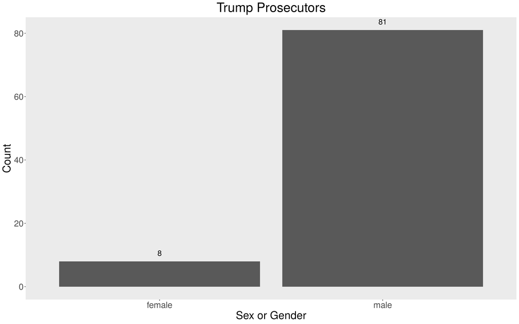

```r
ggplot(df_wiki, aes(sex_or_genderLabel, ..count..)) +
  geom_bar() +
  labs(title = "Trump Prosecutors", x = "Sex or Gender", y = "Count", fill = "") +
  geom_text(stat = 'count', aes(label = ..count..), vjust = -1, size = 6) +
  theme(plot.title = element_text(hjust = 0.5),panel.grid = element_blank(),
        text = element_text(size = 24))
```

### Age

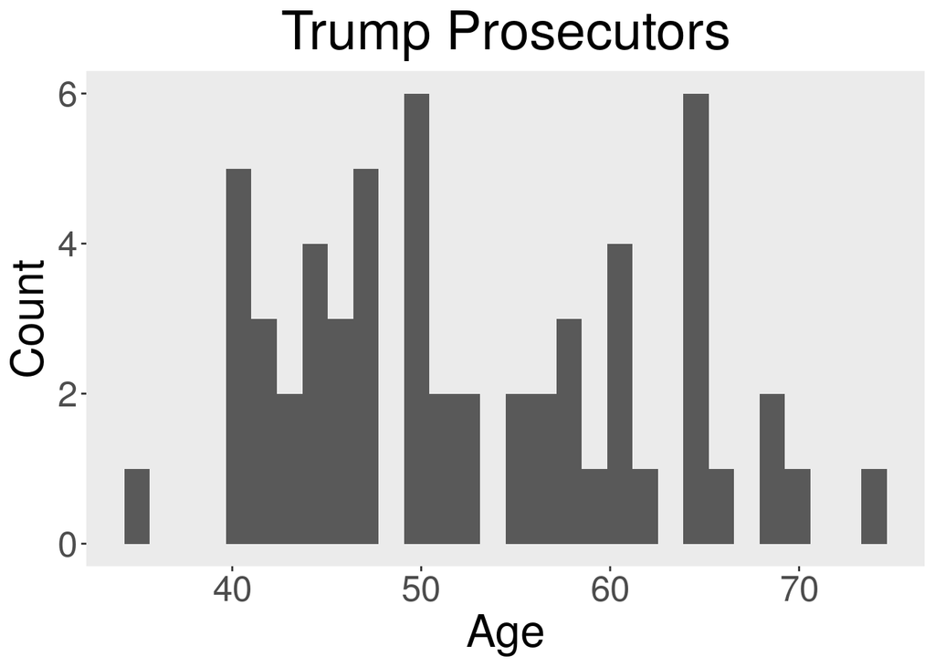

```r
ggplot(df_wiki, aes(age, ..count..)) +
  geom_histogram() +
  labs(title = "Trump Prosecutors", x = "Age", y = "Count", fill = "") +
  theme(plot.title = element_text(hjust = 0.5),panel.grid = element_blank(),
        text = element_text(size = 24))
```

## Merge wikidata with base

We then merge these new covariates with the initial list of prosecutors so all the data is in one place

```r
df_full <- dplyr::left_join(df, df_wiki, by = c('wikidata_id' = 'id'))

# Only keep non-redundant rows
df_full <- df_full %>% dplyr::select(c("itemLabel", "district", "date_of_appointment", "barr_appointment", "sex_or_genderLabel", "date_of_birth", "place_of_birthLabel", "age")) %>%
  dplyr::rename(sex = sex_or_genderLabel, birthplace = place_of_birthLabel)
```

## Save

Save this version of the data

```r
df_full <- write.csv(df_full, paste0(here::here(), "/data/", "prosecutors_base.csv"))
```

# Employment

When then repeat the process for employment data

## Load

This section loads a spreadsheet where we have collected employment history on each personnel from bloomberg profiles, government webpages on each prosecutor, and their linkedin profiles. For law firms, data on ideology was collected from Bonica, Chilton, and Sen (https://chicagounbound.uchicago.edu/cgi/viewcontent.cgi?article=2446&context=law_and_economics).

```r
#work <- googlesheets4::read_sheet(ss = "https://docs.google.com/spreadsheets/d/1hPOBOyTujUReQzpjZ9PqIhj23V5C74EygMnmXIi6BgI/edit?usp=sharing",
#                                    sheet = "prosecutors_employ",
#                                  col_types = "cccccnnnc")

work <- read.csv(file = paste0(here::here(), '/data/raw/TrumpProsecutors - prosecutors_employ.csv'))

work <- janitor::clean_names(work)
```

## Clean

```r
# Check any notes
unique(work$notes)
```

```
## [1] ""
## [2] "Prosecutor for the Mar-A-Lago vandalism case"
## [3] "Counsel, Fmr. New Jersey Gov. Chris Christie"
## [4] "Co-Partner w / Rudy Guliani (Trump's personal attorney)"
```

```r
work$notes <- NULL

# Check employer strings
sort(unique(work$employer))
```

```
##   [1] "(US) Army"
##   [2] "(US) Coast Guard"
##   [3] "(US) Department of the Navy"
##   [4] "(US) Federal Bureau of Investigation"
##   [5] "(US) Marine Corps"
##   [6] "(US) Marine Corps "
##   [7] "(US) Office of President"
##   [8] "19th Judicial District LA "
##   [9] "20th Judicial District of Arkansas"
##  [10] "25th Judicial District TN"
##  [11] "Allstate Insurance Co"
##  [12] "Alston & Bird LLP"
##  [13] "Alston Hunt Floyd & Ing"
##  [14] "Arizona Office of the Attorney General"
##  [15] "Arkansas Public Service Commission"
```

[output cut: 228 more lines]

```r
# Fix start and end date
work$start_date[work$start_date == "Unknown"] <- NA
work$end_date[work$end_date == "Unknown"] <- NA
```

## Prep for network

We are interested in whether any of these people had the same past employers. We look at any employer that more than one prosecutor worked at at any point in time

```r
# Places of employment with the most unique attorneys
work_count <- work %>% dplyr::select(attorney, employer) %>%
  dplyr::distinct() %>%
  dplyr::group_by(employer) %>%
  dplyr::summarise(count = dplyr::n()) %>%
  dplyr::filter(count > 1)

DT::datatable(work_count)
```

|  | employer | count |
| --- | --- | --- |
| 1 | (US) Department of the Navy | 2 |
| 2 | (US) Marine Corps | 2 |
| 3 | Gibson, Dunn &amp; Crutcher LLP | 2 |
| 4 | Goodwin Procter LLP | 2 |
| 5 | Iran - US Claims Tribunal | 2 |
| 6 | Jenner &amp; Block LLP | 2 |
| 7 | Jones Day LLP | 3 |
| 8 | King &amp; Spalding LLP | 2 |
| 9 | Kirkland &amp; Ellis LLP | 2 |
| 10 | Oklahoma Office of the Attorney General | 2 |

[output cut: 19 more lines]

## Save

Since the unit of analysis here is the prosecutor-employment as opposed to prosecutor, we save it as a separate dataset that will be merged in later

```r
work <- work %>% dplyr::select(attorney, employer, firm_conservative_score, start_date, end_date)

work <- write.csv(work, paste0(here::here(), "/data/", "prosecutors_employment.csv"))
```

# School

We repeat the process for educational history. The initial list of educational history was extracted from wikidata, but it does not tell us what degree the prosecutors got from each institution. We want to be able to distinguish law school from undergraduate education. We also add information about the ranking of each undergrad and law school and a measure of law school ideology from data collected by Bonica, Chilton, Rozema, and Sen (https://scholar.harvard.edu/files/msen/files/law-prof-ideology.pdf). Data on law school rankings was collected from Public Legal (https://www.ilrg.com/rankings/law/). ## Load

```r
# edu <- googlesheets4::read_sheet(ss = "https://docs.google.com/spreadsheets/d/1hPOBOyTujUReQzpjZ9PqIhj23V5C74EygMnmXIi6BgI/edit?usp=sharing",
#                                    sheet = "prosecutors_edu",
#                                    col_types = "cccccnnncc")

edu <- read.csv(file = paste0(here::here(), '/data/raw/TrumpProsecutors - prosecutors_edu.csv'))

edu <- janitor::clean_names(edu)
```

## Clean

We collapse all degree types to be bachelors, masters, and law degrees. There were no PhDs in the data

```r
## Collapse degrees
sort(unique(edu$degree))
```

```
##  [1] ""      "AB"    "BA"    "BBA"   "BS"    "JD"    "LLM"   "MA"    "MMgt"
## [10] "MPA"   "MPhil" "MS"
```

```r
edu$degree[edu$degree == "AA" |
             edu$degree == "AB" |
             edu$degree == "BA" |
             edu$degree == "BBA" |
             edu$degree == "BS"] <- "bachelors"

edu$degree[edu$degree == "LLM" |
             edu$degree == "MA" |
             edu$degree == "MMgt" |
             edu$degree == "MPA" |
             edu$degree == "MPhil" |
             edu$degree == "MS"] <- "masters"

edu$degree[edu$degree == "JD"] <- "law"

sort(unique(edu$degree))
```

```
## [1] ""          "bachelors" "law"       "masters"
```

```r
# Accept undergrad LAC rankings as normal, since we're not using them for conservative rankings anyway
edu$undergrad_rank <- stringr::str_replace(edu$undergrad_rank, '\\*', '')
```

## Prep for network

We want to know what prosecutors attended the same law schools, so we clean the data to allow that comparison

```r
# Make wide
edu_clean <- edu %>% dplyr::select(item_label, educated_at_label, degree) %>%
  tidyr::spread(degree, educated_at_label) %>%
  dplyr::select(item_label, bachelors, masters, law)
edu_clean$law <- paste(edu_clean$law, "law", sep = "_")

# Merge, but careful to split undergrad and law
edu_merge <- edu %>% tidyr::unite(educated_combo, educated_at_label, degree, sep = "_", remove = TRUE) %>%
  dplyr::select(educated_combo, law_rank, law_conservative_score) %>%
  dplyr::distinct()

edu_all <- dplyr::left_join(edu_clean, edu_merge, by = c("law" = "educated_combo")) %>%
  dplyr::distinct()
edu_all$law <- gsub("_law", "", paste(edu_all$law))
edu_all$law[edu_all$law == "NA"] <- NA

# Clean each school col
sort(unique(edu_all$bachelors))
```

```
##  [1] "Arkansas State University"
##  [2] "Baylor University"
##  [3] "Binghamton University"
##  [4] "Bowdoin College"
##  [5] "Brandeis University"
##  [6] "Brigham Young University"
##  [7] "Bucknell University"
##  [8] "Carleton College"
##  [9] "Carson Newman University"
## [10] "Centre College"
## [11] "Clemson University"
## [12] "Colgate University"
## [13] "Drury University"
## [14] "Duke University"
## [15] "Florida International University"
```

[output cut: 65 more lines]

```r
sort(unique(edu_all$masters))
```

```
## [1] "American University School of International Service"
## [2] "Auburn University at Montgomery"
## [3] "Oral Roberts University"
## [4] "The Judge Advocate General's Legal Center and School"
## [5] "University of Colorado"
## [6] "University of Glasgow"
## [7] "University of Missouri"
## [8] "University of New Hampshire"
## [9] "University of Washington"
```

```r
sort(unique(edu_all$law))
```

```
##  [1] "American University"
##  [2] "Benjamin N. Cardozo School of Law"
##  [3] "Boston College"
##  [4] "Boston University"
##  [5] "Capital University"
##  [6] "Columbia University"
##  [7] "Cumberland University"
##  [8] "DePaul University"
##  [9] "Dickinson Law"
## [10] "Fordham University"
## [11] "George Washington University"
## [12] "Georgetown University"
## [13] "Gonzaga University"
## [14] "Harvard University"
## [15] "Howard University"
```

[output cut: 52 more lines]

## Results

```r
DT::datatable(edu_all)
```

|  | item_label | bachelors | masters | law | law_rank | law_conservative_score |
| --- | --- | --- | --- | --- | --- | --- |
| 1 | Aaron L. Weisman | Brandeis University |  | Benjamin N. Cardozo School of Law | 43 | -0.839 |
| 2 | Andrew B. Birge | Carleton College |  | Columbia University | 3 | -0.882 |
| 3 | Andrew Lelling | Binghamton University |  | University of Pennsylvania | 6 | -0.865 |
| 4 | Ariana Fajardo Orshan | Florida International University |  | Nova Southeastern University | 157 | -0.224 |
| 5 | B. J. Pak | Stetson University |  | University of Illinois | 36 | -0.865 |
| 6 | Bart Davis | Brigham Young University |  | University of Idaho | 115 | 0.212 |
| 7 | Billy J. Williams | Washington State University |  | Willamette University | 136 | -0.571 |
| 8 | Bobby Christine | University of Georgia |  | Cumberland University | 148 | 0.382 |
| 9 | Brandon J. Fremin | Southeastern Louisiana University |  | Louisiana State University | 102 | 0.278 |
| 10 | Brian Kuester | University of Central Missouri |  | University of Tulsa | 102 | -0.109 |

[output cut: 86 more lines]

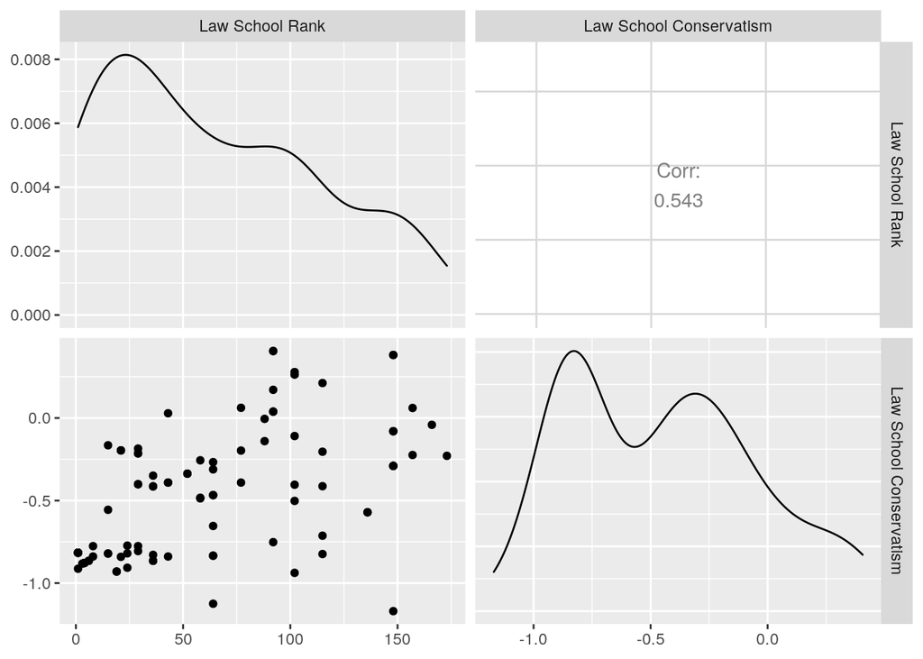

```r
GGally::ggpairs(edu_all[ , c('law_rank', 'law_conservative_score')], columnLabels = c("Law School Rank", "Law School Conservatism"))
```

## Save

```r
edu <- write.csv(edu_all, paste0(here::here(), "/data/", "prosecutors_edu.csv"))
```

# Memberships

We then collected data on US prosecutor membership in various conservative organizations. The two primary organizations of interest are the Federalist Society and the Heritage Foundation. Additional information was collected on other organizations where the data was available. ## Load

```r
# memb <- googlesheets4::read_sheet(ss = "https://docs.google.com/spreadsheets/d/1hPOBOyTujUReQzpjZ9PqIhj23V5C74EygMnmXIi6BgI/edit?usp=sharing",
#                                    sheet = "prosecutors_memb")

memb <- read.csv(file = paste0(here::here(), '/data/raw/TrumpProsecutors - prosecutors_memb.csv'))

memb <- janitor::clean_names(memb)
```

## Prep for network

We organize the data so we can see overlapping memberships

```r
# Make wide
memb_clean <- memb %>% dplyr::select(district, attorney, political_affiliation, dplyr::ends_with("_tie"))
```

## Results

We see a high amount of membership in conservative organizations. Of the 96 prosecutors in the data, roughly 1/3 have documented membership or affiliations with influential conservative organizations.

```r
DT::datatable(memb_clean)
```

|  | district | attorney | political_affiliation | federalist_society_tie | heritage_foundation_tie | national_rifle_association_tie | american_center_for_law_and_justice_tie | republican_national_lawyers_association_tie | christian_legal_society_bar_association_tie |
| --- | --- | --- | --- | --- | --- | --- | --- | --- | --- |
| 1 | U.S. Attorney for the M.D. of Alabama | Louis V. Franklin | None |  |  |  |  |  |  |
| 2 | U.S. Attorney for the N.D. of Alabama | Jay Town | Republican |  |  |  |  |  |  |
| 3 | U.S. Attorney for the S.D. of Alabama | Richard W. Moore | None |  |  |  |  |  |  |
| 4 | U.S. Attorney for the District of Alaska | Bryan Schroder |  |  |  |  |  |  |  |
| 5 | U.S. Attorney for the District of Arizona | Michael G. Bailey | Republican |  |  |  |  |  |  |
| 6 | U.S. Attorney for the E.D. of Arkansas | J. Cody Hiland | Republican |  |  |  |  |  |  |
| 7 | U.S. Attorney for the W.D. of Arkansas | Duane Kees | Republican | 1 |  | 1 | 1 |  |  |
| 8 | U.S. Attorney for the C.D. of California | Nicola T. Hanna | Republican |  |  |  |  |  |  |
| 9 | U.S. Attorney for the E.D. of California | McGregor W. Scott | Republican | 1 |  |  |  |  |  |
| 10 | U.S. Attorney for the N.D. of California | David L. Anderson |  | 1 |  |  |  |  |  |

[output cut: 86 more lines]

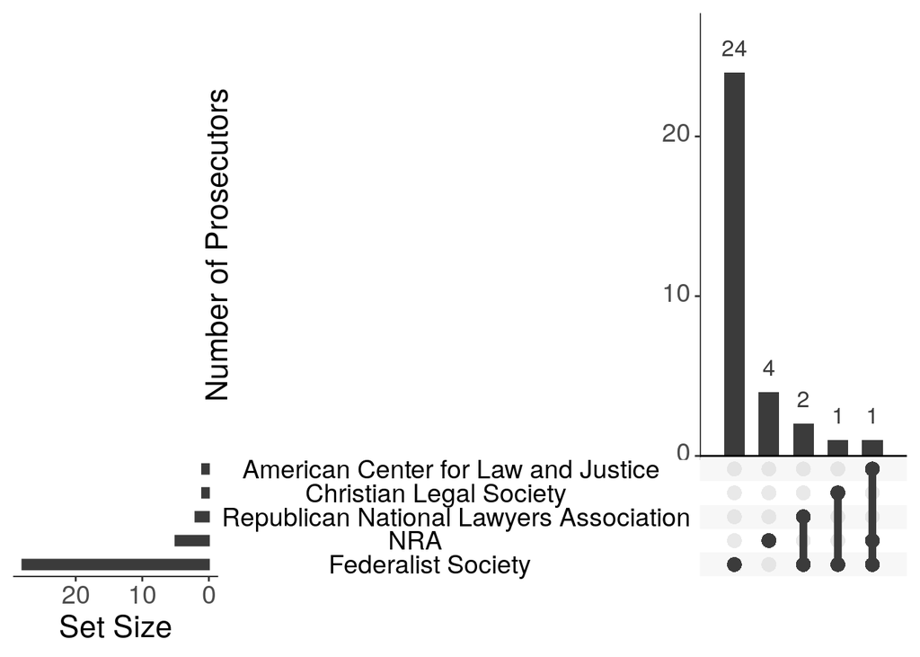

```r
memb_upset <- memb %>% dplyr::select(dplyr::ends_with("_tie")) %>%
  dplyr::rename("Federalist Society" = federalist_society_tie, "Heritage Foundation" = heritage_foundation_tie, "NRA" = national_rifle_association_tie, "American Center for Law and Justice" = american_center_for_law_and_justice_tie, "Republican National Lawyers Association" = republican_national_lawyers_association_tie, "Christian Legal Society" = christian_legal_society_bar_association_tie)

memb_upset <- as.data.frame(sapply(memb_upset, as.numeric))
memb_upset[is.na(memb_upset)] <- 0

UpSetR::upset(memb_upset,
      number.angles = 0, point.size = 3.5, line.size = 2, text.scale = 2,
      mainbar.y.label = "Number of Prosecutors", order.by = "freq")
```

# Final

We load and merge all these portios of the data; demographic, employment, education, and membership, into a single dataset on US prosecutors ## Load all cleaned

```r
# Load
base <- read.csv(paste0(here::here(), "/data/", "prosecutors_base.csv"))
employ <- read.csv(paste0(here::here(), "/data/", "prosecutors_employment.csv"))
edu <- read.csv(paste0(here::here(), "/data/", "prosecutors_edu.csv"))
memb <- read.csv(paste0(here::here(), "/data/", "prosecutors_membership.csv"))
```

## Clean

```r
colnames(base)
```

```
## [1] "X"                   "itemLabel"           "district"
## [4] "date_of_appointment" "barr_appointment"    "sex"
## [7] "date_of_birth"       "birthplace"          "age"
```

```r
base <- base %>% dplyr::select(-c("X")) %>%
  dplyr::rename(person = itemLabel)

colnames(employ)
```

```
## [1] "X"                       "attorney"
## [3] "employer"                "firm_conservative_score"
## [5] "start_date"              "end_date"
```

```r
employ <- employ %>% dplyr::select(-c("X")) %>%
  dplyr::rename(person = attorney)

colnames(edu)
```

```
## [1] "X"                      "item_label"             "bachelors"
## [4] "masters"                "law"                    "law_rank"
## [7] "law_conservative_score"
```

```r
edu <- edu %>% dplyr::select(-c("X")) %>%
  dplyr::rename(person = item_label)

colnames(memb)
```

```
##  [1] "X"
##  [2] "district"
##  [3] "attorney"
##  [4] "political_affiliation"
##  [5] "federalist_society_tie"
##  [6] "heritage_foundation_tie"
##  [7] "national_rifle_association_tie"
##  [8] "american_center_for_law_and_justice_tie"
##  [9] "republican_national_lawyers_association_tie"
## [10] "christian_legal_society_bar_association_tie"
```

```r
memb <- memb %>% dplyr::select(-c("X")) %>%
  dplyr::rename(person = attorney)
```

## Merge

Since the only one with more columns is employment, we merge everything into that

```r
full <- dplyr::left_join(employ, base)
full <- dplyr::left_join(full, edu)
full <- dplyr::left_join(full, memb)
full <- full %>% dplyr::distinct()
```

## Save

```r
write.csv(full, paste0(here::here(), "/data/", "prosecutors_final.csv"))
```